# Lab 4

STAT 302

*If you collaborated with anyone, you must include “Collaborated with: FIRSTNAME LASTNAME” at the top of your lab!*

## Part 1. Training and Test Error (10 points)

Use the following code to generate data:

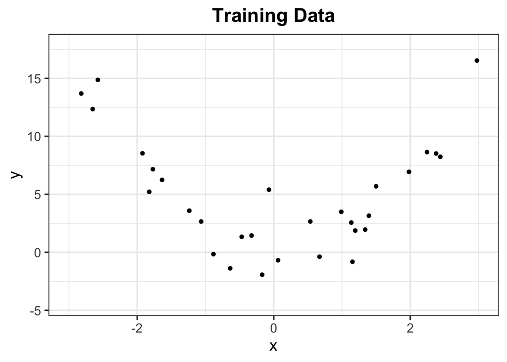

```r
library(ggplot2)
# generate data
set.seed(302)
n <- 30
x <- sort(runif(n, -3, 3))
y <- 2*x^2 + 2*rnorm(n)
x_test <- sort(runif(n, -3, 3))
y_test <- 2*x_test^2 + 2*rnorm(n)
df_train <- data.frame("x" = x, "y" = y)
df_test <- data.frame("x" = x_test, "y" = y_test)

# store a theme
my_theme <- theme_bw(base_size = 16) +
  theme(plot.title = element_text(hjust = 0.5, face = "bold"),
        plot.subtitle = element_text(hjust = 0.5))

# generate plots
g_train <- ggplot(df_train, aes(x = x, y = y)) + geom_point() +
  xlim(-3, 3) + ylim(min(y, y_test), max(y, y_test)) +
  labs(title = "Training Data") + my_theme
g_test <- ggplot(df_test, aes(x = x, y = y)) + geom_point() +
  xlim(-3, 3) + ylim(min(y, y_test), max(y, y_test)) +
  labs(title = "Test Data") + my_theme
g_train
```

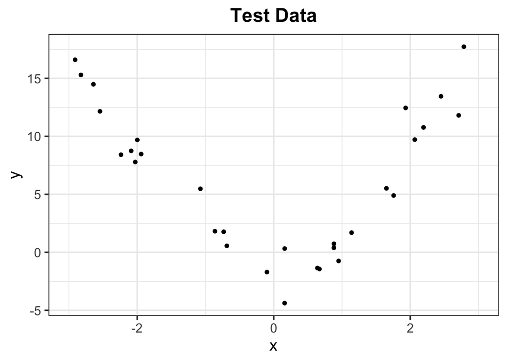

```r
g_test
```

**1a.** For every k in between 1 and 10, fit a degree-k polynomial linear regression model with `y` as the response and `x` as the explanatory variable(s). (*Hint: Use* `poly()`*, as in the lecture slides.*)

**1b.** For each model from (a), record the training error. Then predict `y_test` using `x_test` and also record the test error. (*Hint: You can either do this part by copying your code 10 times for each value of k (which is totally fine!), or in a loop (if you are struggling to call your model within a loop check out the functions get() and paste0()*)

**1c.** Present the 10 values for both training error and test error on a single table. Comment on what you notice about the relative magnitudes of training and test error, as well as the trends in both types of error as $k$ increases.

**1d.** If you were going to choose a model based on training error, which would you choose? Plot the data, colored by split (training or test split). Add a line to the plot representing your selection for model fit. Add a subtitle to this plot with the (rounded!) test error. (*Hint: See Lecture Slides 8 for example code.*)

**1e.** If you were going to choose a model based on test error, which would you choose? Plot the data, colored by split. Add a line to the plot representing your selection for model fit. Add a subtitle to this plot with the (rounded!) test error.

**1f.** What do you notice about the shape of the curves from part (d) and (e)? Which is more flexible? Why should we trust our test error more than our training error in this context?

## Part 2. k-Nearest Neighbors Cross-Validation (10 points)

For this part, note that there are tidyverse methods to perform cross-validation in R (see the `rsample` package). However, your goal is to understand and be able to implement the algorithm “by hand”, meaning that automated procedures from the `rsample` package, or similar packages, will not be accepted.

To begin, load in the popular `penguins` data set from the package `palmerpenguins`. Use the dataframe `peng_clean` for your analysis to avoid missing data.

```r
library(palmerpenguins)
data("penguins")
peng_clean <- penguins %>%
  mutate(any_nas = is.na(bill_length_mm) | is.na(bill_depth_mm) |
           is.na(flipper_length_mm) | is.na(body_mass_g)) %>%
  filter(!any_nas)
```

Our goal here is to predict output class `species` using covariates `bill_length_mm`, `bill_depth_mm`, `flipper_length_mm`, and `body_mass_g`. All your code should be within a function `my_knn_cv`.

**Input:**

- `train`: input data frame
- `cl`: true class value of your training data
- `k_nn`: integer representing the number of neighbors
- `k_cv`: integer representing the number of folds

*Please note the distinction between `k_nn` and `k_cv`!*

**Output:** a list with objects

- `class`: a vector of the predicted class $\hat{Y}_{i}$ for all observations
- `cv_err`: a numeric with the cross-validation misclassification error

You will need to include the following steps:

- Within your function, define a variable `fold` that randomly assigns observations to folds $1,\ldots,k$ with equal probability. (*Hint: see the example code on the slides for k-fold cross validation*)
- Iterate through $i = 1:k$.
  - Within each iteration, use `knn()` from the `class` package to predict the class of the $i$th fold using all other folds as the training data.
  - Also within each iteration, record the misclassification rate (a value between 0 and 1 representing the proportion of observations that were classified **incorrectly**).
- After you have done the above steps for all $k$ iterations, store the vector `class` as the output of `knn()` with the full data as both the training and the test data, and the value `cv_error` as the average misclassification rate from your cross validation.

**Submission:** To prove your function works, apply it to the `penguins` data (using `peng_clean`). Predict output class `species` using covariates `bill_length_mm`, `bill_depth_mm`, `flipper_length_mm`, and `body_mass_g`. Use $5$-fold cross validation (`k_cv = 5`). Use a table to show the `cv_err` values for 1-nearest neighbor and 5-nearest neighbors (`k_nn = 1` and `k_nn = 5`), as well as the training set error values for 1 and 5 nearest neighbors (compare your output `class` to the true class, `penguins$species`). Comment on which value had lower CV misclassification error and which had lower training set error. Which model would you choose based on this analysis? Why?